# Impact of major weather events on U.S public health and economy (1950-2011)

Daniel Pont

2018-09-20

## Synopsis

In this report we aim to present the impact on public health and economy of major weather events in the United States between 1950 and november 2011. We obtained and analyzed the U.S. National Oceanic and Atmospheric Administration’s (NOAA) storm database for this period. The database tracks characteristics of major storms and weather events in the United States, including when and where they occur, as well as estimates of any fatalities, injuries, and property damage. From these data, we found that :

- Fatalies are mostly due to tornadoes, followed far behind by excessive heat and flash floods
- Injuries apart from tornadoes, heat and floods are caused by wind and lightnings
- Property Damages are mainly caused by floods
- Crop Damages are mainly caused by droughts

## Loading and processing the data

From the he U.S. National Oceanic and Atmospheric Administration’s (NOAA) [Storm database](https://d396qusza40orc.cloudfront.net/repdata%2Fdata%2FStormData.csv.bz2) we obtained raw data. National Weather Service provides [Storm Data Documentation](https://d396qusza40orc.cloudfront.net/repdata%2Fpeer2_doc%2Fpd01016005curr.pdf). The National Climatic Data Center also provides [Storm events FAQ](https://d396qusza40orc.cloudfront.net/repdata%2Fpeer2_doc%2FNCDC%20Storm%20Events-FAQ%20Page.pdf).

### Reading in the data

We first download the compressed csv datafile into the “./data” directory (automatically created if it doesn’t exist), then load the file it in The R environement. We use the file first line as header to define the dataset column names.

```r
url <- "https://d396qusza40orc.cloudfront.net/repdata%2Fdata%2FStormData.csv.bz2"
dataDir <- "data"
dataFile <- paste(dataDir,"StormData.csv.bz2",sep="/")
if(!dir.exists(dataDir)){
    dir.create(dataDir)
}
download.file(url,destfile=dataFile)
data <- read.table(file = dataFile, sep = ",",header=TRUE)
```

We then check the dimension and the structure of the dataset

```r
str(data)
```

```
## 'data.frame':    902297 obs. of  37 variables:
##  $ STATE__   : num  1 1 1 1 1 1 1 1 1 1 ...
##  $ BGN_DATE  : Factor w/ 16335 levels "1/1/1966 0:00:00",..: 6523 6523 4242 11116 2224 2224 2260 383 3980 3980 ...
##  $ BGN_TIME  : Factor w/ 3608 levels "00:00:00 AM",..: 272 287 2705 1683 2584 3186 242 1683 3186 3186 ...
##  $ TIME_ZONE : Factor w/ 22 levels "ADT","AKS","AST",..: 7 7 7 7 7 7 7 7 7 7 ...
##  $ COUNTY    : num  97 3 57 89 43 77 9 123 125 57 ...
##  $ COUNTYNAME: Factor w/ 29601 levels "","5NM E OF MACKINAC BRIDGE TO PRESQUE ISLE LT MI",..: 13513 1873 4598 10592 4372 10094 1973 23873 24418 4598 ...
##  $ STATE     : Factor w/ 72 levels "AK","AL","AM",..: 2 2 2 2 2 2 2 2 2 2 ...
##  $ EVTYPE    : Factor w/ 985 levels "   HIGH SURF ADVISORY",..: 834 834 834 834 834 834 834 834 834 834 ...
##  $ BGN_RANGE : num  0 0 0 0 0 0 0 0 0 0 ...
##  $ BGN_AZI   : Factor w/ 35 levels "","  N"," NW",..: 1 1 1 1 1 1 1 1 1 1 ...
##  $ BGN_LOCATI: Factor w/ 54429 levels "","- 1 N Albion",..: 1 1 1 1 1 1 1 1 1 1 ...
##  $ END_DATE  : Factor w/ 6663 levels "","1/1/1993 0:00:00",..: 1 1 1 1 1 1 1 1 1 1 ...
##  $ END_TIME  : Factor w/ 3647 levels ""," 0900CST",..: 1 1 1 1 1 1 1 1 1 1 ...
##  $ COUNTY_END: num  0 0 0 0 0 0 0 0 0 0 ...
```

[output cut: 23 more lines]

For our analysis the relevant variables are :

- **EVTYPE** : the type of weather event
- **FATALITIES** : the number of fatalities
- **INJURIES** : the number of injuries
- **PROPDMG** / **PROPDMGEXP** : the cost of property damage
- **CROPDMG** / **CROPDMGEXP** : the cost of crop damage

### Processing the data relative to fatalities

We extract the total fatalities by event type and order them in descending order. Doing so ensures that the event types with the highest fatalities are on top of the dataset.

```r
fatalitiesByEvType <- data %>%
                    select(FATALITIES,EVTYPE)%>%
                    filter(FATALITIES!=0)%>%
                    group_by(EVTYPE) %>%
                    summarize(FATALITIES=sum(FATALITIES)) %>%
                    arrange(desc(FATALITIES))
```

Let’s check the dimension of fatalitiesByEvType :

```r
dim(fatalitiesByEvType)
```

```
## [1] 168   2
```

There are 168 observations. We take a glance at the first rows, to get an idea of which event types cause the highest fatalities :

```r
head(fatalitiesByEvType,n=10)
```

```
## # A tibble: 10 x 2
##    EVTYPE         FATALITIES
##    <fct>               <dbl>
##  1 TORNADO              5633
##  2 EXCESSIVE HEAT       1903
##  3 FLASH FLOOD           978
##  4 HEAT                  937
##  5 LIGHTNING             816
##  6 TSTM WIND             504
##  7 FLOOD                 470
##  8 RIP CURRENT           368
##  9 HIGH WIND             248
## 10 AVALANCHE             224
```

Judging by the result above, we can focus on a small subset of event types which cause the vast majority of fatalities. We’ll select the first 25.

```r
fatalitiesByEvType <- fatalitiesByEvType[1:25,]
```

### Processing the data relative to the injuries

We extract the total injuries by event type and order them in descending order. Doing so ensures that the event types with the highest injuries are on top of the dataset.

```r
injuriesByEvType <- data %>%
    select(INJURIES,EVTYPE)%>%
    filter(INJURIES!=0)%>%
    group_by(EVTYPE) %>%
    summarize(INJURIES=sum(INJURIES)) %>%
    arrange(desc(INJURIES))
```

Let’s check the dimension of injuriesByEvType :

```r
dim(injuriesByEvType)
```

```
## [1] 158   2
```

There are 158 observations, the first rows are :

```r
head(injuriesByEvType,n=10)
```

```
## # A tibble: 10 x 2
##    EVTYPE            INJURIES
##    <fct>                <dbl>
##  1 TORNADO              91346
##  2 TSTM WIND             6957
##  3 FLOOD                 6789
##  4 EXCESSIVE HEAT        6525
##  5 LIGHTNING             5230
##  6 HEAT                  2100
##  7 ICE STORM             1975
##  8 FLASH FLOOD           1777
##  9 THUNDERSTORM WIND     1488
## 10 HAIL                  1361
```

As we noted with the fatalities, a few event types are responsible for a vast percentage of the injuries. Hence we’ll keep only the 25 first rows.

```r
injuriesByEvType <- injuriesByEvType[1:25,]
```

### Processing the data relative to the property and crop damages

Property and crop damages are measured with 4 variables :

- **PROPDMG** / **PROPDMGEXP**
- **CROPDMG** / **CROPDMGEXP**

PROPDMG and CROPDMG contain numeric values so their can be processed in a straight forward fashion.

PROPDMGEXP and CROPDMGEXP are alphanumeric factors. We have to examine them more closely

```r
table(data$PROPDMGEXP)
```

```
##
##             -      ?      +      0      1      2      3      4      5
## 465934      1      8      5    216     25     13      4      4     28
##      6      7      8      B      h      H      K      m      M
##      4      5      1     40      1      6 424665      7  11330
```

```r
table(data$CROPDMGEXP)
```

```
##
##             ?      0      2      B      k      K      m      M
## 618413      7     19      1      9     21 281832      1   1994
```

By examining PROPDMGEXP and CROPDMGEXP, we understand they are exponents that should be multiplied respectively by PROPDMG and CROPDMG. Their numerical values equivalent are listed in the following table ;

| PROPDMGEXP / CROPDMGEXP | numeric value |
| --- | --- |
| b, B | 1 000 000 000 |
| m, M | 1 000 000 |
| k, K | 1 000 |
| h, H | 100 |

The exponent values absent from this table (-,?,+0,1,2,3,..) are more difficult to understand. Due to their very low frequency, we’ll ignore them.

To calculate damage cost from both PROPDMG/PROPDMGEXP and CROPDMG/CROPDMGEXP we’ll use the following function

```r
calculateValue <- function(base,exp){
    if (!is.numeric(base))
    {
        return(0)
    }
    value <- 0
    exp <- tolower(exp)
    if(exp==""){
        value <- base
    }
    if(exp=="b"){
        value <- base*10^9
    } else if(exp=="m"){
        value <- base*10^6
    } else if(exp=="k"){
        value <- base*1000
    }
    else if(exp=="h"){
        value <- base*100
    }
    return(value)
}
```

We select the columns EVTYPE, PROPDMG, PROPDMGEXP, CROPDMG, CROPDMGEXP from the orignal dataset and add 2 columns :

- PROPERTY.DAMAGE = calculateValue(PROPDMG,PROPDMGEXP)
- CROP.DAMAGE = calculateValue(CROPDMG,CROPDMGEXP)

thus we get the dataset “damages” :

```r
damages <- data %>% select(EVTYPE,PROPDMG,PROPDMGEXP,CROPDMG,CROPDMGEXP) %>%
            rowwise() %>%
            mutate(PROPERTY.DAMAGE=calculateValue(PROPDMG,PROPDMGEXP))
damages <-  damages %>%
            rowwise() %>%
            mutate(CROP.DAMAGE=calculateValue(CROPDMG,CROPDMGEXP))
```

Applying the same methodology we used for fatalities and injuries, we calculate the sum of PROPERTY.DAMAGE and CROP.DAMAGE by event type :

```r
damagesByEvType <- damages %>%
                    group_by(EVTYPE) %>%
                    summarize(PROPERTY.DAMAGE=sum(PROPERTY.DAMAGE),
                              CROP.DAMAGE=sum(CROP.DAMAGE) )
```

next we add a new column TOTAL = PROPERTY.DAMAGE+CROP.DAMAGE to the dataset “damagesByEvType”

```r
damagesByEvType$TOTAL <-    damagesByEvType$PROPERTY.DAMAGE +
                            damagesByEvType$CROP.DAMAGE
```

then we ensure that the highest TOTAL values are at the top of “damagesByEvType”

```r
damagesByEvType <- damagesByEvType %>% arrange(desc(TOTAL))
```

now we can take a quick glance at the processed data :

```r
head(damagesByEvType,n=10)
```

```
## # A tibble: 10 x 4
##    EVTYPE            PROPERTY.DAMAGE CROP.DAMAGE        TOTAL
##    <fct>                       <dbl>       <dbl>        <dbl>
##  1 FLOOD                144657709807  5661968450 150319678257
##  2 HURRICANE/TYPHOON     69305840000  2607872800  71913712800
##  3 TORNADO               56937160483   414953110  57352113593
##  4 STORM SURGE           43323536000        5000  43323541000
##  5 HAIL                  15732267277  3025954453  18758221730
##  6 FLASH FLOOD           16140811717  1421317100  17562128817
##  7 DROUGHT                1046106000 13972566000  15018672000
##  8 HURRICANE             11868319010  2741910000  14610229010
##  9 RIVER FLOOD            5118945500  5029459000  10148404500
## 10 ICE STORM              3944927810  5022113500   8967041310
```

as with the fatalities and injuries, a small subset of event types are responsible for the main damages. We’ll focus on the 15 leading ones.

```r
damagesByEvType <- damagesByEvType[1:15,]
```

## Results

### Fatalities

The total number of fatalities per weather event type can be displayed with a bar plot, as follows :

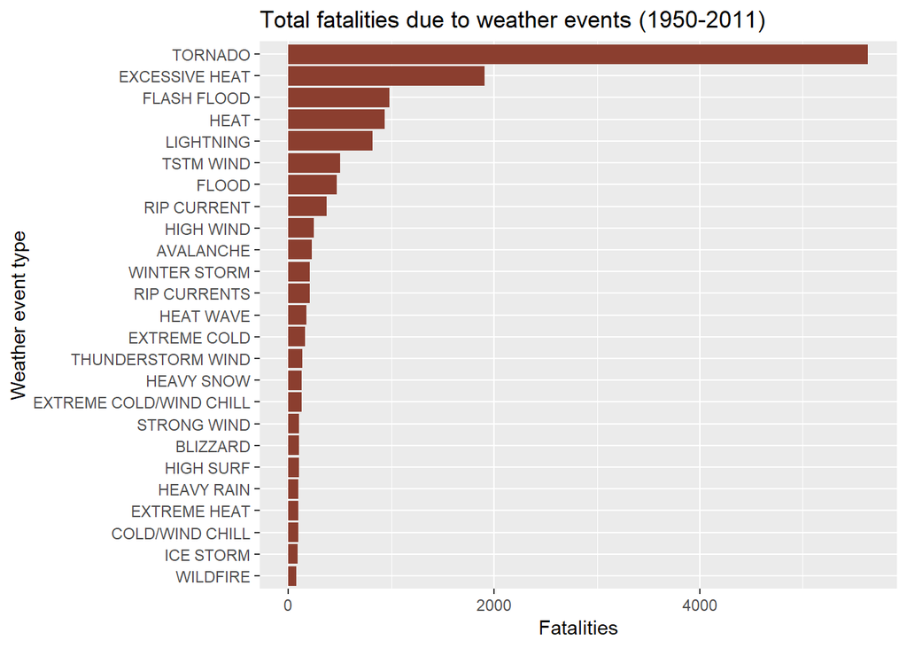

```r
g <- ggplot(fatalitiesByEvType, aes(x=EVTYPE,y=FATALITIES))
g +
    # stat="identity" : use y=FATALITIES instead of the default count(EVTYPE)
    geom_bar(stat="identity", fill="coral4") +
    # plot a horizontal bar graph with the max value bar at the top position:
    scale_x_discrete(limits=rev(fatalitiesByEvType$EVTYPE)) +coord_flip()+
    # make sure that the title and labels are explicit and readable
    labs(y="Fatalities")+
    labs(x="Weather event type")+
    labs(title="Total fatalities due to weather events (1950-2011)")
```

The plot is quite explicit :

1. tornadoes are the most lethal weather event type
2. in second position comes high temperature (excessive heat and heat)
3. in third position comes flash floods / floods

### Injuries

The total number of injuries per weather event type can be displayed with a bar plot, as follows :

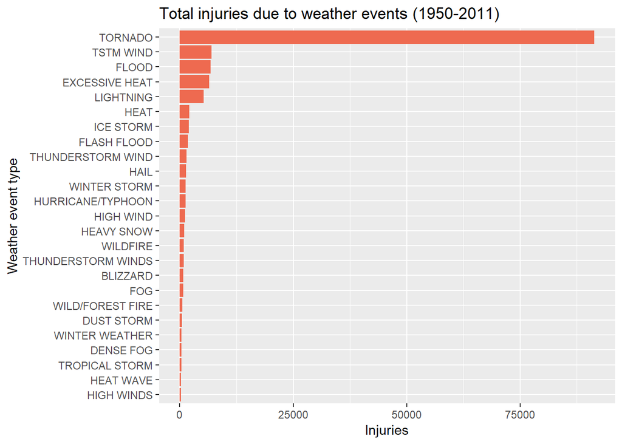

```r
g <- ggplot(injuriesByEvType, aes(x=EVTYPE,y=INJURIES))
g +
    # stat="identity" : use y=INJURIES instead of the default count(EVTYPE)
    geom_bar(stat="identity",fill="coral2") +
    # plot a horizontal bar graph with the max value bar at the top position:
    scale_x_discrete(limits=rev(injuriesByEvType$EVTYPE)) +coord_flip()+
    # make sure that the title and labels are explicit and readable
    labs(y="Injuries")+
    labs(x="Weather event type")+
    labs(title="Total injuries due to weather events (1950-2011)")
```

### Property and crop damages

To display property and crop damages on the same figure, we’ll use a stack bar plot. In order to exploit ggpot2 native features, we’ll have to reshape the dataset “damagesByEvType”.

From the dataset “damagesByEvType” which has the following columns :

- EVTYPE
- PROPERTY.DAMAGE
- CROP.DAMAGE
- TOTAL

We’ll build a new dataset “damagesPlotDat” which as the folllowing columns :

- Event.Type (=EVTYPE)
- Damage.Type (property/crop)
- Damage.Cost

This can be done with a few lines of code thanks to the package “reshape” :

```r
damagesPlotData <- damagesByEvType %>%  select(EVTYPE,property=PROPERTY.DAMAGE,crop=CROP.DAMAGE )
damagesPlotData <- melt(data = as.data.frame(damagesPlotData),id=c("EVTYPE"))
names(damagesPlotData) <- c("Event.Type","Damage.Type","Damage.Cost")
```

Plotting this reshaped dataset is now quite straight forward :

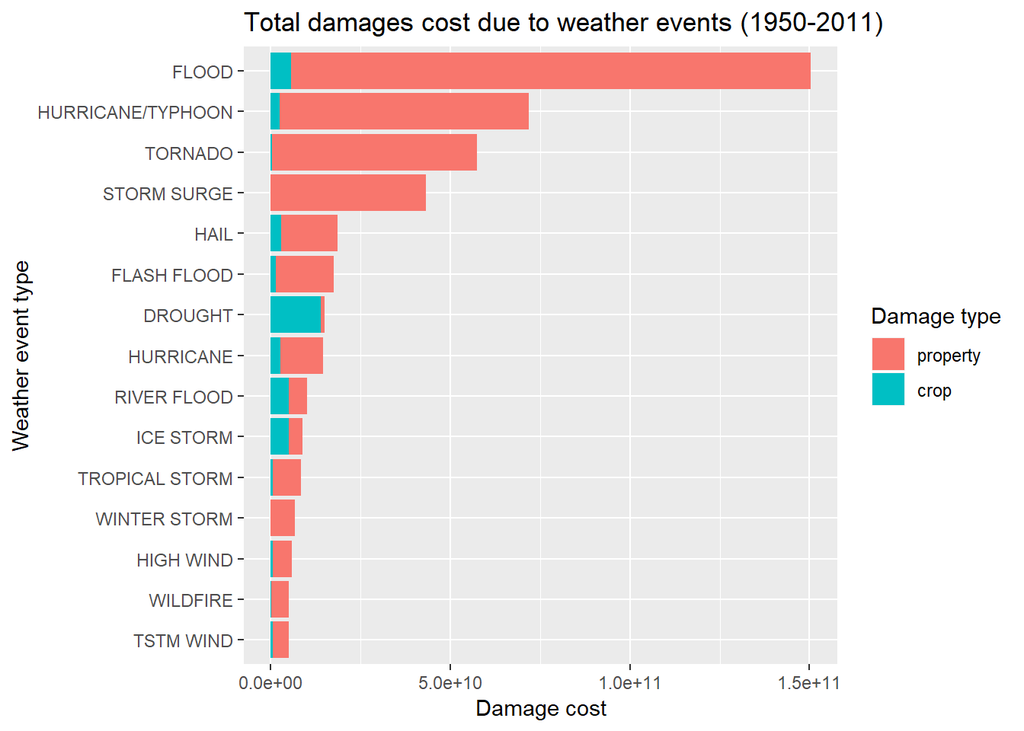

```r
g <- ggplot(data = damagesPlotData, aes(x = Event.Type, y = Damage.Cost, fill = Damage.Type))
g +
    # stat="identity" : use y=Damage.Cost instead of the default count(EVTYPE)
    geom_bar(stat="identity") +
    # plot a horizontal bar graph with the max value bar at the top position:
    scale_x_discrete(limits=rev(damagesByEvType$EVTYPE)) + coord_flip()+
    # make sure that the title and labels are explicit and readable
    labs(y="Damage cost")+
    labs(x="Weather event type")+
    scale_fill_discrete(name="Damage type") +
    labs(title="Total damages cost due to weather events (1950-2011)")
```

From this plot we conclude that :

- The main cause of material damages are floods, hurricanes/typhoons, tornadoes and storm surges
- On the whole property damages are much higher than crop damages (even if they are exceptions : droughts for instance cause significantly higher crop damages than property damages)